# R Common Plot Formatting Code

```r
library(tidyverse)
penguins <- read_csv("../data/penguins.csv")
```

## Adjusting Title and Labels

An easy way to adjust the title and labels of a ggplot are to use the labs() function. This allows you to specify a title (using the title argument) and axes labels using the x and y arguments.

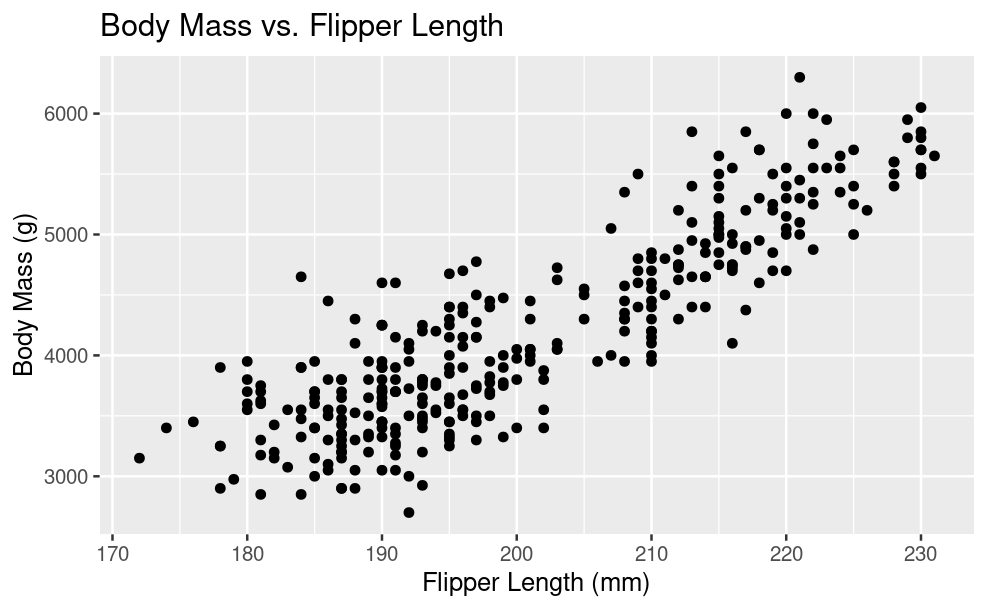

```r
penguins |>
  ggplot(aes(x = flipper_length_mm, y = body_mass_g)) +
  geom_point() +
  labs(
    title = "Body Mass vs. Flipper Length",
    x = "Flipper Length (mm)",
    y = "Body Mass (g)"
    )
```

## Adjusting Ticks

If you want to adjust the ticks, you can use the scale_[axis]_[variable type] functions. Let’s say we wanted to customize the ticks on the x-axis. We could use the scale_x_continuous function:

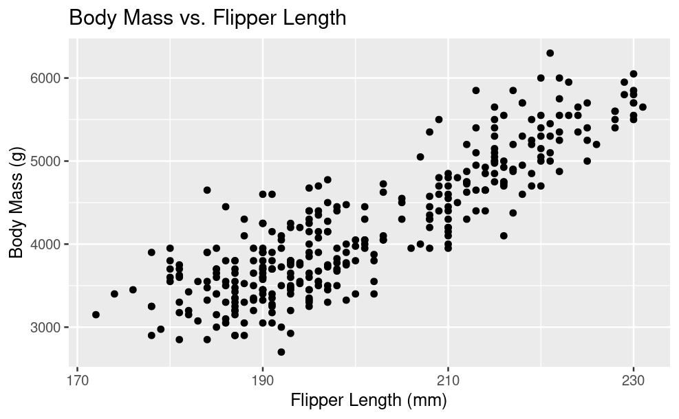

```r
penguins |>
  ggplot(aes(x = flipper_length_mm, y = body_mass_g)) +
  geom_point() +
  labs(
    title = "Body Mass vs. Flipper Length",
    x = "Flipper Length (mm)",
    y = "Body Mass (g)"
    ) +
  scale_x_continuous(breaks = c(170, 190, 210, 230))
```

If you want to change the axis limits, you can do so using the limits argument:

[figure not shown]

To add commas to the ticks on the y-axis, we can use the scale_y_continuous function. Note that we need to load in the scales library for this to work.

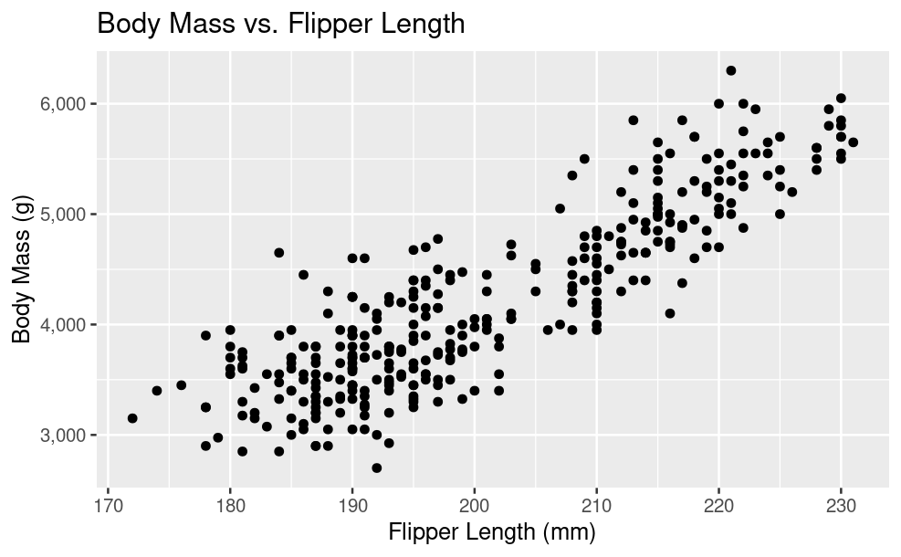

```r
library(scales)
penguins |>
  ggplot(aes(x = flipper_length_mm, y = body_mass_g)) +
  geom_point() +
  labs(
    title = "Body Mass vs. Flipper Length",
    x = "Flipper Length (mm)",
    y = "Body Mass (g)"
    ) +
  scale_y_continuous(labels = comma)
```

On the other hand, if my x variable is categorical, I need to use scale_x_discrete. For example, to rotate the axis labels, I can use the guide argument.

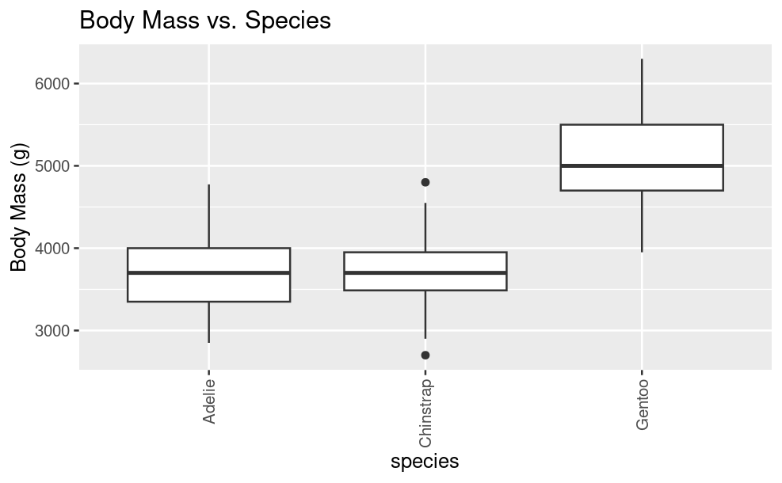

```r
penguins |>
  ggplot(aes(x = species, y = body_mass_g)) +
  geom_boxplot() +
  labs(title = "Body Mass vs. Species",
       y = "Body Mass (g)") +
  scale_x_discrete(guide = guide_axis(angle = 90))
```

Let’s say I want to lowercase the labels. In this case I can use an anonymous function as the labels argument to accomplish this.

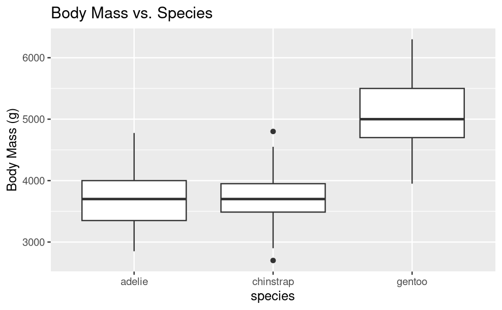

```r
penguins |>
  ggplot(aes(x = species, y = body_mass_g)) +
  geom_boxplot() +
  labs(title = "Body Mass vs. Species",
       y = "Body Mass (g)") +
  scale_x_discrete(labels = ~str_to_lower(.))
```

If you’re working with money, you can also use the dollar_format function from the scales library.

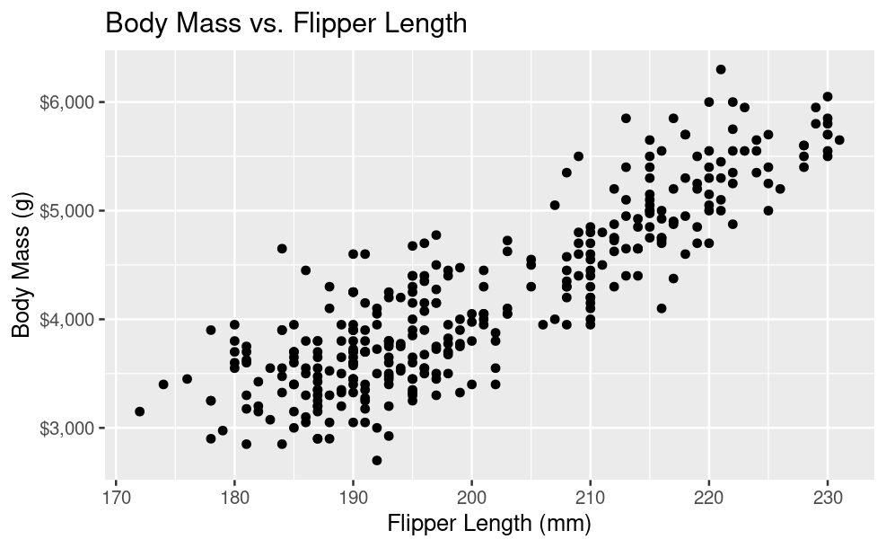

```r
penguins |>
  ggplot(aes(x = flipper_length_mm, body_mass_g)) +
  geom_point() +
  labs(
    title = "Body Mass vs. Flipper Length",
    x = "Flipper Length (mm)",
    y = "Body Mass (g)"
    ) +
  scale_y_continuous(labels = dollar_format())
```

## Customizing Colors

To customize the colors on a plot, you can use the scale_color_[type] functions. For a categorical variable, you can use scale_color_manual to specify the colors to use.

[figure not shown]

For a continuous colorscale, you could use the scale_color_distiller function and specify a palette.

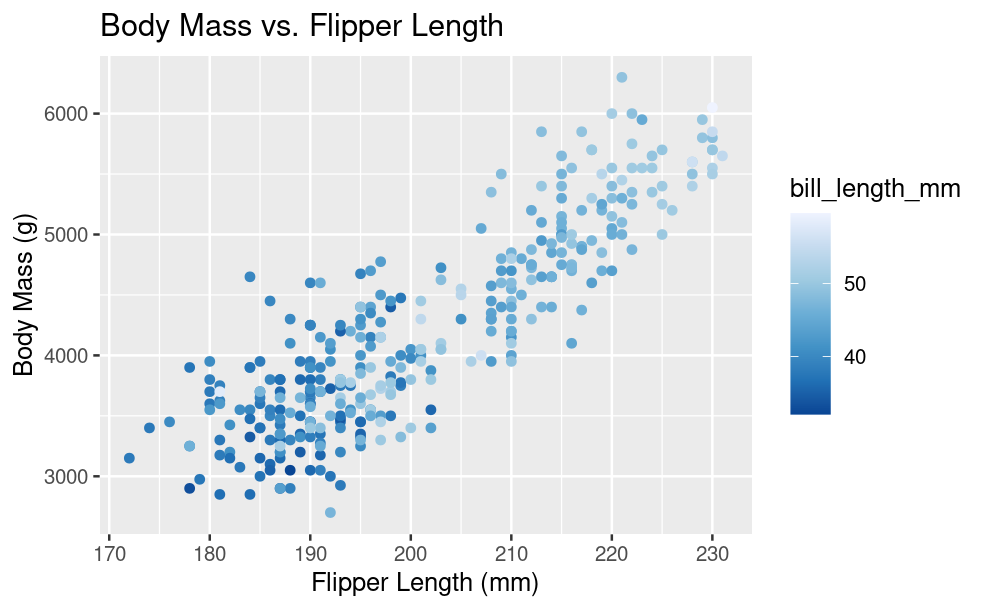

```r
penguins |>
  ggplot(aes(x = flipper_length_mm, y = body_mass_g, color = bill_length_mm)) +
  geom_point() +
  labs(
    title = "Body Mass vs. Flipper Length",
    x = "Flipper Length (mm)",
    y = "Body Mass (g)"
    ) +
  scale_color_distiller(palette = "Blues")
```

If you want to adjust the legend name, you can use name argument of the scale_color function that you are using.

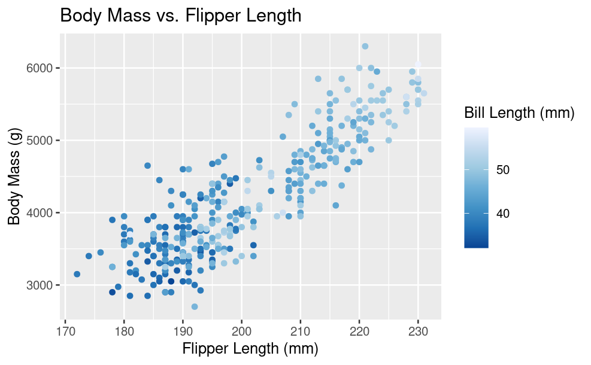

```r
penguins |>
  ggplot(aes(x = flipper_length_mm, y = body_mass_g, color = bill_length_mm)) +
  geom_point() +
  labs(
    title = "Body Mass vs. Flipper Length",
    x = "Flipper Length (mm)",
    y = "Body Mass (g)"
    ) +
  scale_color_distiller(palette = "Blues", name = "Bill Length (mm)")
```

Alternatively, you could use the labs function to adjust the name:

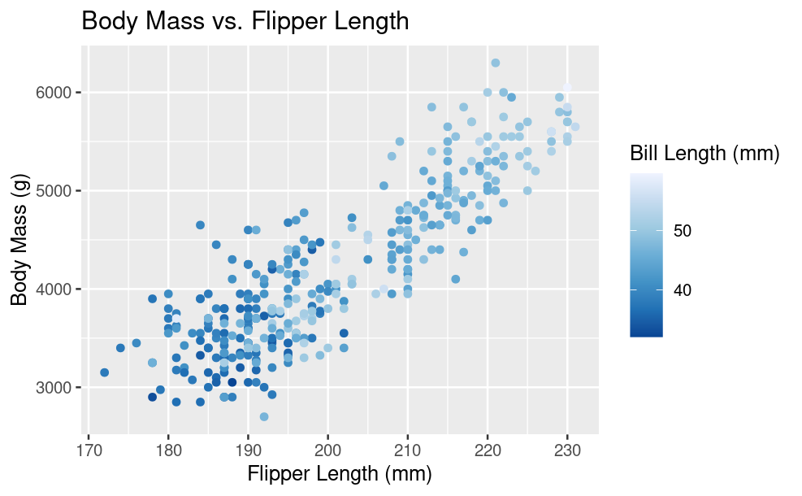

```r
penguins |>
  ggplot(aes(x = flipper_length_mm, y = body_mass_g, color = bill_length_mm)) +
  geom_point() +
  labs(
    title = "Body Mass vs. Flipper Length",
    x = "Flipper Length (mm)",
    y = "Body Mass (g)",
    color = "Bill Length (mm)"
    ) +
  scale_color_distiller(palette = "Blues")
```